# Regression Analysis and Visualization

```r
library(clinpubr)
library(dplyr)
library(survival)
library(ggplot2)
```

## Introduction

The `clinpubr` package provides a comprehensive suite for regression analysis in clinical research, supporting Cox proportional hazards, logistic, and linear regression with publication-ready visualizations. This vignette covers the typical analysis workflow:

1. **Regression Scan** — Screen predictors with multiple transformations
2. **Comprehensive Results** — Generate multi-model specification tables
3. **Forest Plots** — Visualize effect sizes
4. **Predictor Effects** — RCS plots and effect plots
5. **Interaction Analysis** — Test and visualize effect modification
6. **Subgroup Analysis** — Subgroup forest plots

The `clinpubr` package supports frequently used regression models: **Cox Proportional Hazards**, **Logistic Regression**, **Linear Regression**, and provides unified interface for them. The model used would be infered based on the settings of the `y` and `time` arguments. If `y` is binary and `time` is given, the model would be Cox Proportional Hazards; if `y` is a binary variable, and `time` not given, the model would be Logistic Regression; if `y` is a continuous variable, the model would be Linear Regression.

## Data Preparation

We’ll use the NCCTG Lung Cancer dataset (228 patients with advanced lung cancer):

```r
data(cancer, package = "survival")
cancer$dead <- cancer$status == 2

cancer_clean <- cancer %>%
  mutate(
    sex = factor(sex, labels = c("Male", "Female"))
  ) %>%
  na.omit()

knitr::kable(data.frame(
  Rows = nrow(cancer_clean),
  Columns = ncol(cancer_clean),
  Description = "Complete cases for analysis"
), caption = "Analysis Dataset Summary")
```

Analysis Dataset Summary

| Rows | Columns | Description |
| --- | --- | --- |
| 167 | 11 | Complete cases for analysis |

```r
knitr::kable(head(cancer_clean), caption = "Sample of Analysis Variables")
```

Sample of Analysis Variables

|  | inst | time | status | age | sex | ph.ecog | ph.karno | pat.karno | meal.cal | wt.loss | dead |
| --- | --- | --- | --- | --- | --- | --- | --- | --- | --- | --- | --- |
| 2 | 3 | 455 | 2 | 68 | Male | 0 | 90 | 90 | 1225 | 15 | TRUE |
| 4 | 5 | 210 | 2 | 57 | Male | 1 | 90 | 60 | 1150 | 11 | TRUE |
| 6 | 12 | 1022 | 1 | 74 | Male | 1 | 50 | 80 | 513 | 0 | FALSE |
| 7 | 7 | 310 | 2 | 68 | Female | 2 | 70 | 60 | 384 | 10 | TRUE |
| 8 | 11 | 361 | 2 | 71 | Female | 2 | 60 | 80 | 538 | 1 | TRUE |
| 9 | 1 | 218 | 2 | 53 | Male | 1 | 70 | 80 | 825 | 16 | TRUE |

## Regression Scan

`regression_scan()` automatically tests multiple variable transformations for each predictor:

- **Original** (linear) form
- **Logarithmic** transformation (if all values > 0)
- **Categorical** form (median split)
- **RCS** (Restricted Cubic Spline) for non-linear relationships

### Cox Proportional Hazards Model

```r
cox_scan <- regression_scan(
  data = cancer_clean,
  y = "status",
  time = "time",
  # set predictors = NULL to scan all available variables
  # predictors = NULL,
  predictors = c("age", "sex", "ph.karno", "pat.karno", "wt.loss", "meal.cal"),
  covars = NULL,
  save_table = FALSE
)

knitr::kable(cox_scan, caption = "Cox Regression Scan Results")
```

Cox Regression Scan Results

|  | predictor | nvalid | original.HR | original.pval | original.padj | logarithm.HR | logarithm.pval | logarithm.padj | categorized.HR | categorized.pval | categorized.padj | rcs.overall.pval | rcs.overall.padj | rcs.nonlinear.p | best.var.trans |
| --- | --- | --- | --- | --- | --- | --- | --- | --- | --- | --- | --- | --- | --- | --- | --- |
| 4 | pat.karno | 167 | 0.9812708 | 0.0021995 | 0.0131971 | 0.2933451 | 0.0024286 | 0.0097142 | 0.5831016 | 0.0038615 | 0.0193076 | 0.0210379 | 0.0698049 | 0.9680713 | original |
| 2 | sex | 167 | 0.6192558 | 0.0147907 | 0.0443721 | NA | NA | NA | NA | NA | NA | NA | NA | NA | original |
| 1 | age | 167 | 1.0200874 | 0.0641959 | 0.1029532 | 3.2622315 | 0.0688278 | 0.1275780 | 1.3335186 | 0.1177009 | 0.1471261 | 0.1464013 | 0.1830016 | 0.4447903 | original |
| 3 | ph.karno | 167 | 0.9878729 | 0.0686354 | 0.1029532 | 0.4378243 | 0.0956835 | 0.1275780 | 0.6274233 | 0.0184766 | 0.0461915 | 0.0279220 | 0.0698049 | 0.0803601 | categorized |
| 6 | meal.cal | 167 | 0.9998804 | 0.6209701 | 0.7451641 | 0.8967025 | 0.5548170 | 0.5548170 | 0.8640874 | 0.4291805 | 0.4291805 | 0.7222351 | 0.7222351 | 0.6013624 | categorized |
| 5 | wt.loss | 167 | 1.0001532 | 0.9817372 | 0.9817372 | NA | NA | NA | 1.4330287 | 0.0527764 | 0.0879607 | 0.1053526 | 0.1755877 | 0.0466637 | categorized |

The scan reports the effect size, p-value, adjusted p-value (BH correction by default), and the best transformation.

### Logistic Regression Scan

```r
logistic_scan <- regression_scan(
  data = cancer_clean,
  y = "dead",
  predictors = c("age", "sex", "ph.karno", "pat.karno", "wt.loss"),
  covars = NULL,
  save_table = FALSE
)

knitr::kable(logistic_scan, caption = "Logistic Regression Scan Results")
```

Logistic Regression Scan Results

|  | predictor | nvalid | original.OR | original.pval | original.padj | logarithm.OR | logarithm.pval | logarithm.padj | categorized.OR | categorized.pval | categorized.padj | rcs.overall.pval | rcs.overall.padj | rcs.nonlinear.p | best.var.trans |
| --- | --- | --- | --- | --- | --- | --- | --- | --- | --- | --- | --- | --- | --- | --- | --- |
| 2 | sex | 167 | 0.3742964 | 0.0053682 | 0.0268408 | NA | NA | NA | NA | NA | NA | NA | NA | NA | original |
| 4 | pat.karno | 167 | 0.9701901 | 0.0184097 | 0.0460243 | 0.1480629 | 0.0465029 | 0.0465029 | 0.4427438 | 0.0373640 | 0.0498187 | 0.0689533 | 0.1457501 | 0.5271516 | original |
| 3 | ph.karno | 167 | 0.9703678 | 0.0396626 | 0.0528173 | 0.0984975 | 0.0461388 | 0.0465029 | 0.3157895 | 0.0161386 | 0.0475296 | 0.0995735 | 0.1457501 | 0.2382474 | categorized |
| 1 | age | 167 | 1.0389903 | 0.0422538 | 0.0528173 | 10.2713218 | 0.0335189 | 0.0465029 | 1.7416268 | 0.1120568 | 0.1120568 | 0.1457501 | 0.1457501 | 0.5010354 | logarithm |
| 5 | wt.loss | 167 | 1.0084347 | 0.5300552 | 0.5300552 | NA | NA | NA | 2.2308546 | 0.0237648 | 0.0475296 | 0.1176075 | 0.1457501 | 0.0679239 | categorized |

## Comprehensive Regression Results

In clinical publications, it’s standard to present multiple model specifications (Crude, Partially adjusted, Fully adjusted) to show how confounding affects the estimated association.

### Cox Model with Multiple Specifications

```r
cox_results <- regression_basic_results(
  data = cancer_clean,
  x = "age",
  y = "status",
  time = "time",
  model_covs = list(
    Crude = c(),
    Model1 = c("sex"),
    Model2 = c("sex", "ph.karno", "pat.karno")
  ),
  pers = c(1, 5, 10),
  save_output = FALSE
)

knitr::kable(cox_results$table, caption = "Cox Regression Results for Age")
```

Cox Regression Results for Age

| Terms | Count | Crude | Crude | Model1 | Model1 | Model2 | Model2 |
| --- | --- | --- | --- | --- | --- | --- | --- |
| age (All) | 167 | HR | P | HR | P | HR | P |
| Continuous | NA | 1.02(1.00,1.04) | 0.064 | 1.02(1.00,1.04) | 0.109 | 1.01(0.99,1.03) | 0.352 |
| Continuous, per 1 | NA | 1.02(1.00,1.04) | 0.064 | 1.02(1.00,1.04) | 0.109 | 1.01(0.99,1.03) | 0.352 |
| Continuous, per 5 | NA | 1.10(0.99,1.23) | 0.064 | 1.09(0.98,1.21) | 0.109 | 1.06(0.94,1.18) | 0.352 |
| Continuous, per 10 | NA | 1.22(0.99,1.51) | 0.064 | 1.19(0.96,1.47) | 0.109 | 1.11(0.89,1.40) | 0.352 |
| Continuous, per 1 SD | NA | 1.20(0.99,1.46) | 0.064 | 1.17(0.97,1.43) | 0.109 | 1.10(0.90,1.36) | 0.352 |
| Continuous, logarithm | NA | 3.26(0.91,11.66) | 0.069 | 2.79(0.78,10.06) | 0.116 | 1.89(0.49,7.34) | 0.359 |
| Grouped by Quartiles | NA | NA | NA | NA | NA | NA | NA |
| Q1 | 41 | 1 (Reference) | NA | 1 (Reference) | NA | 1 (Reference) | NA |
| Q2 | 42 | 0.79(0.46,1.34) | 0.373 | 0.72(0.42,1.23) | 0.228 | 0.71(0.42,1.22) | 0.215 |
| Q3 | 40 | 1.03(0.61,1.73) | 0.905 | 0.98(0.58,1.65) | 0.941 | 0.87(0.51,1.49) | 0.613 |
| Q4 | 44 | 1.34(0.81,2.20) | 0.256 | 1.23(0.75,2.04) | 0.414 | 1.08(0.64,1.83) | 0.775 |
| P for trend | NA | NA | 0.144 | NA | 0.208 | NA | 0.561 |
| Grouped by Median Value | NA | NA | NA | NA | NA | NA | NA |
| Low | 83 | 1 (Reference) | NA | 1 (Reference) | NA | 1 (Reference) | NA |
| High | 84 | 1.33(0.93,1.91) | 0.118 | 1.31(0.92,1.88) | 0.138 | 1.16(0.79,1.71) | 0.437 |

### Logistic Model with Clinical Cut-points

```r
logistic_results <- regression_basic_results(
  data = cancer_clean,
  x = "ph.karno",
  y = "dead",
  model_covs = list(
    Crude = c(),
    Adjusted = c("age", "sex")
  ),
  factor_breaks = c(80),
  factor_labels = c("<80", ">=80"),
  save_output = FALSE
)

knitr::kable(logistic_results$table, caption = "Logistic Regression Results for Performance Status")
```

Logistic Regression Results for Performance Status

| Terms | Count | Crude | Crude | Adjusted | Adjusted |
| --- | --- | --- | --- | --- | --- |
| ph.karno (All) | 167 | OR | P | OR | P |
| Continuous | NA | 0.97(0.94,1.00) | 0.040 | 0.97(0.94,1.00) | 0.085 |
| Continuous, per 0.1 | NA | 1.00(0.99,1.00) | 0.040 | 1.00(0.99,1.00) | 0.085 |
| Continuous, per 10 | NA | 0.74(0.55,0.98) | 0.040 | 0.76(0.55,1.03) | 0.085 |
| Continuous, per 100 | NA | 0.05(0.003,0.80) | 0.040 | 0.07(0.003,1.36) | 0.085 |
| Continuous, per 1 SD | NA | 0.68(0.47,0.97) | 0.040 | 0.71(0.47,1.04) | 0.085 |
| Continuous, logarithm | NA | 0.10(0.009,0.87) | 0.046 | 0.12(0.009,1.34) | 0.097 |
| Grouped by Quartiles | NA | NA | NA | NA | NA |
| Q1 | 20 | 1 (Reference) | NA | 1 (Reference) | NA |
| Q2 | 24 | 2.75(0.48,21.64) | 0.275 | 2.58(0.43,20.67) | 0.314 |
| Q3 | 47 | 0.53(0.14, 1.76) | 0.326 | 0.56(0.14, 1.99) | 0.393 |
| Q4 | 76 | 0.48(0.13, 1.47) | 0.229 | 0.50(0.12, 1.69) | 0.291 |
| P for trend | NA | NA | 0.039 | NA | 0.077 |
| Grouped by Median Value | NA | NA | NA | NA | NA |
| Low | 44 | 1 (Reference) | NA | 1 (Reference) | NA |
| High | 123 | 0.32(0.11,0.76) | 0.016 | 0.34(0.12,0.88) | 0.035 |
| Grouped by Clinical Value | NA | NA | NA | NA | NA |
| <80 | 44 | 1 (Reference) | NA | 1 (Reference) | NA |
| >=80 | 123 | 0.32(0.11,0.76) | 0.016 | 0.34(0.12,0.88) | 0.035 |

### Quantile-Based Categories

When clinical cut-points aren’t established, use tertiles for balanced group comparison:

```r
custom_results <- regression_basic_results(
  data = cancer_clean,
  x = "age",
  y = "status",
  time = "time",
  quantile_breaks = c(0.33, 0.67),
  quantile_labels = c("Youngest Third", "Middle Third", "Oldest Third"),
  label_with_range = TRUE,
  save_output = FALSE
)

knitr::kable(custom_results$table, caption = "Cox Regression Results - Age Tertiles")
```

Cox Regression Results - Age Tertiles

| Terms | Count | Crude | Crude |
| --- | --- | --- | --- |
| age (All) | 167 | HR | P |
| Continuous | NA | 1.02(1.00,1.04) | 0.064 |
| Continuous, per 0.1 | NA | 1.00(1.00,1.00) | 0.064 |
| Continuous, per 10 | NA | 1.22(0.99,1.51) | 0.064 |
| Continuous, per 100 | NA | 7.31(0.89,60.04) | 0.064 |
| Continuous, per 1 SD | NA | 1.20(0.99,1.46) | 0.064 |
| Continuous, logarithm | NA | 3.26(0.91,11.66) | 0.069 |
| Grouped by Quartiles | NA | NA | NA |
| Q1 [39,57) | 41 | 1 (Reference) | NA |
| Q2 [57,64) | 42 | 0.79(0.46,1.34) | 0.373 |
| Q3 [64,70) | 40 | 1.03(0.61,1.73) | 0.905 |
| Q4 [70,82] | 44 | 1.34(0.81,2.20) | 0.256 |
| P for trend | NA | NA | 0.144 |
| Grouped by Median Value | NA | NA | NA |
| Low [39,64) | 83 | 1 (Reference) | NA |
| High [64,82] | 84 | 1.33(0.93,1.91) | 0.118 |
| Values | NA | NA | NA |
| Youngest Third [39,58.8) | 55 | 1 (Reference) | NA |
| Middle Third [58.8,68) | 54 | 0.92(0.58,1.46) | 0.721 |
| Oldest Third [68,82] | 58 | 1.37(0.89,2.13) | 0.154 |
| P for trend | NA | NA | 0.145 |

## Forest Plots

### Univariate Forest Plot

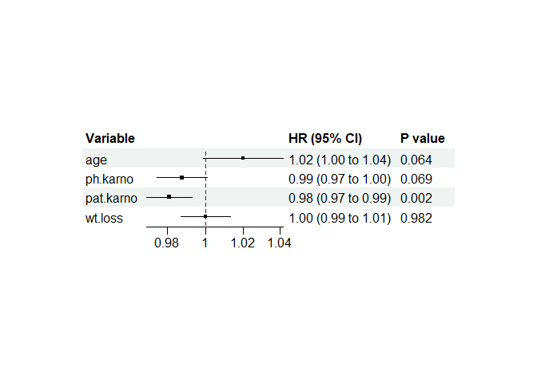

```r
uni_forest <- regression_forest(
  data = cancer_clean,
  model_vars = c("age", "ph.karno", "pat.karno", "wt.loss"),
  y = "status",
  time = "time",
  as_univariate = TRUE, # Generate univariate forest plot
  save_plot = FALSE
)

uni_forest
```

The univariate forest plot displays:

- **Left panel**: Variable names
- **Center**: Forest plot with effect estimates and 95% confidence intervals
  - The function automatically estimates the effect size (HR for Cox model, odds ratio for logistic model, and beta coefficient for linear model)
  - Each square represents the point estimate
  - Horizontal lines represent 95% confidence intervals
  - The vertical dashed line is the reference line, where HR=1.0 (for Cox model) or odds ratio=1.0 (for logistic model) or beta coefficient=0 (for linear model), which indicates no effect
- **Right panel**: Numerical values of effect estimates (95% CI) and p-values

In this example, `pat.karno` shows a significant protective effect (HR ≈ 0.98, p < 0.01), while `age`, `ph.karno`, and `wt.loss` do not reach statistical significance in univariate analysis.

### Multivariate Forest Plot

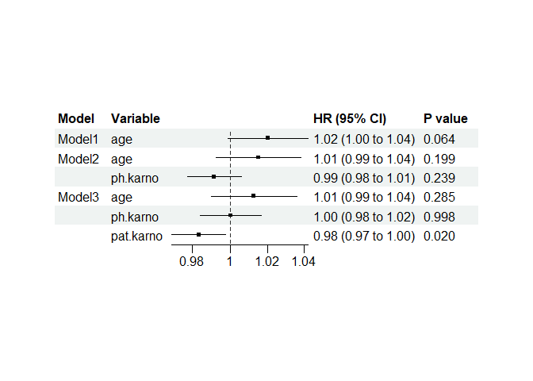

```r
multi_forest <- regression_forest(
  data = cancer_clean,
  model_vars = list(
    Model1 = c("age"),
    Model2 = c("age", "ph.karno"),
    Model3 = c("age", "ph.karno", "pat.karno")
  ),
  y = "status",
  time = "time",
  as_univariate = FALSE, # Generate multivariate forest plot
  save_plot = FALSE
)

multi_forest
```

The multivariate forest plot compares different model specifications:

- **Model1**: Contains only `age` (crude model)
- **Model2**: Contains `age` and `ph.karno` (partially adjusted)
- **Model3**: Contains `age`, `ph.karno`, and `pat.karno` (fully adjusted)

Key observations: - As more covariates are added, the effect estimate for `age` changes slightly - The confidence intervals may widen or narrow depending on the correlation between predictors - This visualization helps assess confounding effects and model stability

### Customizing Forest Plots

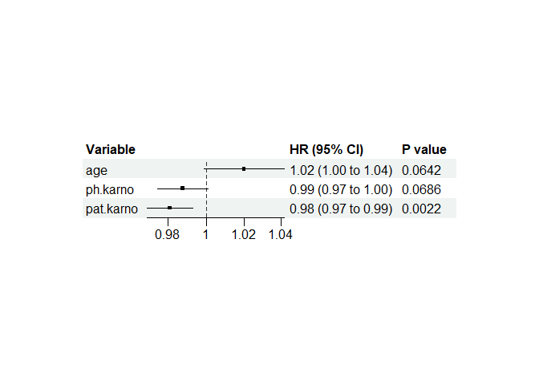

```r
custom_forest <- regression_forest(
  data = cancer_clean,
  model_vars = c("age", "ph.karno", "pat.karno", "wt.loss", "meal.cal"),
  y = "status",
  time = "time",
  as_univariate = TRUE,
  show_vars = c("age", "ph.karno", "pat.karno"),
  est_nsmall = 2,
  p_nsmall = 4,
  save_plot = FALSE
)

custom_forest
```

The customized forest plot demonstrates several formatting options:

- **`show_vars`**: Limits displayed variables to `age`, `ph.karno`, and `pat.karno`
- **`est_nsmall = 2`**: Displays effect estimates with 2 decimal places
- **`p_nsmall = 4`**: Displays p-values with 4 decimal places

This allows focused presentation of key predictors with precise numerical formatting suitable for publication.

## Predictor Effect Visualization

### Predictor Effect Plot

A unified interface for both continuous and categorical predictors:

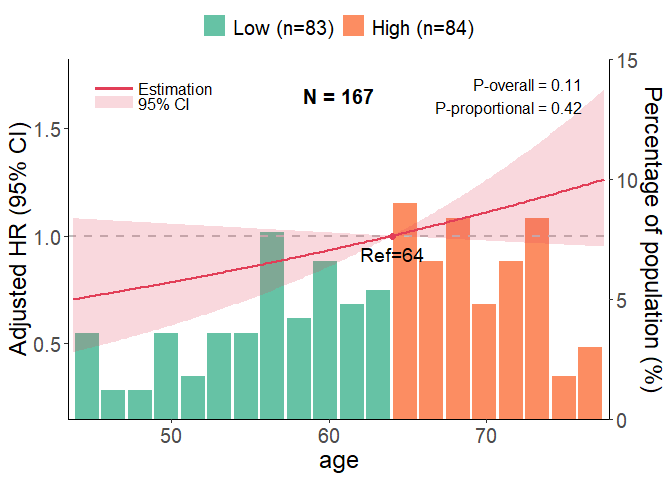

```r
effect_linear <- predictor_effect_plot(
  data = cancer_clean,
  x = "age",
  y = "status",
  time = "time",
  covars = c("sex"),
  method = "linear",
  add_hist = TRUE,
  save_plot = FALSE
)

effect_linear
```

The linear predictor effect plot shows:

- **X-axis**: Age (continuous predictor)
- **Y-axis**: Hazard Ratio (HR) with reference at the median age
- **Solid line**: Estimated HR across age values
- **Shaded area**: 95% confidence interval
- **Histogram**: Distribution of age in the dataset, with the relative frequency on the right y-axis
- **P-overall**: Overall p-value for the model, indicating the significance of the predictor effect
- **P-proportional**: Only exists for Cox model, p-value for the proportional hazard assumption test

This plot assumes a linear relationship between the predictor and outcome, useful for confirming linearity assumptions or presenting simple linear effects.

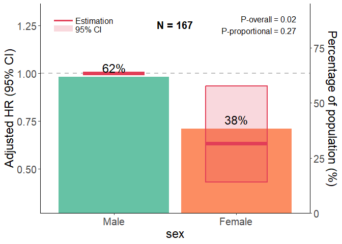

```r
effect_cat <- predictor_effect_plot(
  data = cancer_clean,
  x = "sex",
  y = "status",
  time = "time",
  covars = c("age", "ph.karno"),
  method = "categorical",
  save_plot = FALSE
)

effect_cat
```

The categorical predictor effect plot displays:

- **X-axis**: Categories of the predictor (Male vs Female)
- **Y-axis**: Hazard Ratio with 95% confidence intervals
- **Reference line**: HR = 1.0 (dashed line)
- **Error crossbars**: Point estimates and 95% confidence intervals for each category
- **Bar plot**: Distribution of categories in the dataset, with the percentage on the right y-axis
- **P-overall**: Overall p-value for the model, indicating the significance of the predictor effect
- **P-proportional**: Only exists for Cox model, p-value for the proportional hazard assumption test

In this example, females show a significantly lower hazard compared to males (HR ≈ 0.62, 95% CI does not include 1.0), indicating better survival outcomes for female patients after adjusting for age and performance status.

### RCS Plots

RCS plots visualize non-linear relationships while preserving the continuous nature of the data, the plot can also be generated using `predictor_effect_plot()` with `method = "rcs"`:

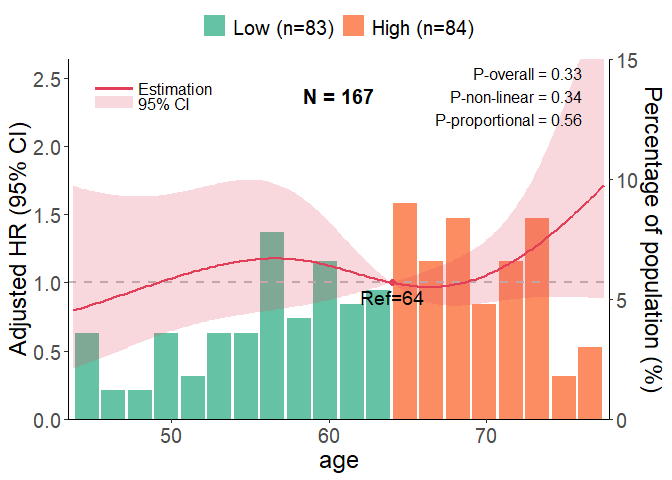

```r
rcs_age <- rcs_plot(
  data = cancer_clean,
  x = "age",
  y = "status",
  time = "time",
  covars = c("sex", "ph.karno"),
  knot = 4,
  ref = "x_median",
  add_hist = TRUE,
  save_plot = FALSE
)

rcs_age
```

The RCS (Restricted Cubic Spline) plot visualizes the non-linear relationship between age and survival, the element interpretation is similar to the linear plot. There is one additional element:

- **P-non-linear**: Non-linear p-value for the model, indicating the significance of the non-linear effect

Key features: - The spline with 4 knots (`knot = 4`) allows flexible modeling of non-linear relationships - Reference point (`ref = "x_median"`) is set at the median age (HR = 1.0) - The plot shows how the hazard changes relative to the median age

### Customized RCS Plot

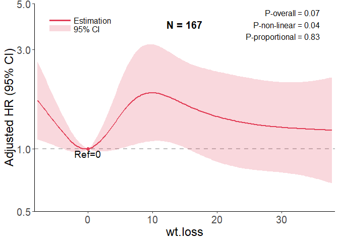

```r
custom_rcs <- rcs_plot(
  data = cancer_clean,
  x = "wt.loss",
  y = "status",
  time = "time",
  covars = c("age", "sex"),
  knot = 5,
  ref = 0,
  add_hist = FALSE,
  trans = "log10",
  y_lim = c(0.5, 5),
  save_plot = FALSE
)

custom_rcs
```

The customized RCS plot demonstrates advanced options:

- **`knot = 5`**: Uses 5 knots for more flexible curve fitting
- **`ref = 0`**: Sets reference point at weight loss = 0 (no weight loss)
- **`trans = "log10"`**: Applies log10 transformation to the y-axis. To enable log-scale y-axis, `add_hist` must be `FALSE`
- **`y_lim = c(0.5, 5)`**: Custom y-axis limits for better visualization
- **`add_hist = FALSE`**: Excludes the histogram for cleaner presentation

This plot examines the relationship between weight loss and survival, with the reference at zero weight loss. The log-scale y-axis helps visualize effect sizes across a wide range.

## Subgroup Analysis

### Scanning for Interactions

Interaction analysis is essential in clinical research to assess whether the effect of a predictor variable on the outcome differs across subgroups defined by another variable (effect modification). In medical papers, this is commonly referred to as **subgroup analysis with interaction testing**.

The `interaction_scan()` function systematically evaluates potential interactions between multiple predictors and grouping variables:

- **Linear interaction (`linear.p.int`)**: Tests whether the linear effect of a predictor differs across subgroups
- **RCS interaction (`rcs.p.int`)**: Tests for non-linear interactions using restricted cubic splines (4 knots)
- **Adjusted p-values**: Both raw and Benjamini-Hochberg (BH) adjusted p-values are provided to control for multiple comparisons
- **Sample size (`nvalid`)**: Reports the number of complete cases for each interaction test

**Clinical interpretation**: A significant interaction p-value (typically < 0.05) indicates that the effect of the predictor on the outcome is modified by the grouping variable, suggesting that treatment effects or risk associations may differ between subgroups.

```r
interaction_scan <- interaction_scan(
  data = cancer_clean,
  y = "status",
  time = "time",
  predictors = c("age", "ph.karno", "pat.karno"),
  group_vars = c("sex", "ph.karno"), # continuous variables will be split by median into subgroups
  save_table = FALSE
)

knitr::kable(interaction_scan, caption = "Interaction Scan Results")
```

Interaction Scan Results

|  | predictor | group.by | nvalid | linear.p.int | rcs.p.int | linear.p.adj | rcs.p.adj |
| --- | --- | --- | --- | --- | --- | --- | --- |
| 2 | age | ph.karno | 167 | 0.0972655 | 0.0117594 | 0.3101036 | 0.0235189 |
| 3 | ph.karno | sex | 167 | 0.1240414 | NA | 0.3101036 | NA |
| 5 | pat.karno | ph.karno | 167 | 0.5731909 | NA | 0.7485232 | NA |
| 1 | age | sex | 167 | 0.6276238 | 0.9342510 | 0.7485232 | 0.9342510 |
| 4 | pat.karno | sex | 167 | 0.7485232 | NA | 0.7485232 | NA |

**Understanding the output columns:**

| Column | Description |
| --- | --- |
| `predictor` | The continuous or categorical variable being tested for effect modification |
| `group.by` | The subgroup variable (e.g., sex) that may modify the predictor’s effect |
| `nvalid` | Number of complete observations used in the interaction test |
| `linear.p.int` | Raw p-value for linear interaction effect |
| `linear.p.adj` | BH-adjusted p-value for linear interaction |
| `rcs.p.int` | Raw p-value for non-linear (RCS) interaction effect |
| `rcs.p.adj` | BH-adjusted p-value for RCS interaction |

### Visualizing Interactions

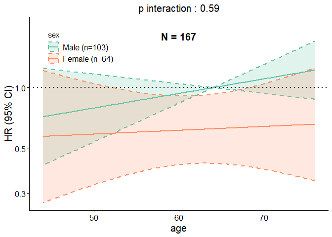

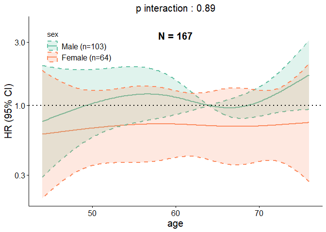

```r
interaction_age_sex <- interaction_plot(
  data = cancer_clean,
  predictor = "age",
  y = "status",
  time = "time",
  group_var = "sex",
  covars = c("ph.karno"),
  save_plot = FALSE
)

interaction_age_sex
```

The interaction plot displays two panels:

**Linear Interaction Plot (`$lin`)**: - Shows the effect of age on survival separately for males and females - Different colored lines represent different sex groups - Parallel lines suggest no interaction; diverging/converging lines suggest interaction - Shaded areas represent 95% confidence intervals

**RCS Interaction Plot (`$rcs`)**: - Shows non-linear effects of age within each sex group - Allows detection of non-linear interactions - Each curve represents the HR relative to the reference point for that sex

In this example, the lines appear roughly parallel, suggesting no significant interaction between age and sex (confirmed by p-value > 0.05).

### Subgroup Forest Plot

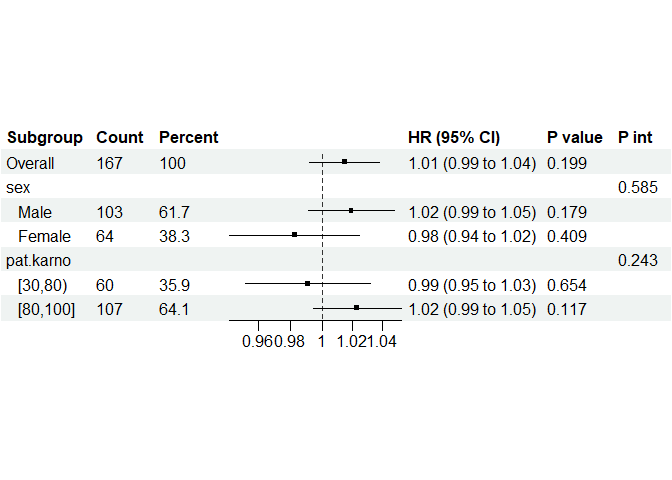

```r
subgroup_result <- subgroup_forest(
  data = cancer_clean,
  x = "age",
  y = "status",
  time = "time",
  subgroup_vars = c("sex", "pat.karno"),
  covars = c("ph.karno"),
  save_plot = FALSE
)

subgroup_result
```

The subgroup forest plot displays the effect of age on survival stratified by groups:

- **Overall**: Effect estimate for the entire cohort
- **Sex**: Effect estimate for each sex group
- **Pat.Karno**: Effect estimate for each patient’s Karno score group

Each row shows: - Sample size for that subgroup - Effect estimate with 95% confidence interval - P-value of interaction

This visualization helps assess: - Whether the effect is consistent across subgroups - Potential effect modification by the stratifying variable

## Summary

| Function | Purpose |
| --- | --- |
| `regression_scan()` | Automated screening of predictors with multiple transformations |
| `regression_basic_results()` | Comprehensive results with various model specifications |
| `regression_forest()` | Publication-ready forest plots |
| `rcs_plot()` / `predictor_effect_plot()` | Flexible visualization of predictor effects |
| `interaction_scan()` / `interaction_plot()` | Interaction analysis and visualization |
| `subgroup_forest()` | Subgroup analysis with forest plots |